# Project 4

## Mini-Project 4: Solving n-queens Problem using Evolutionary Computation

#### CSC 180 Intelligent Systems (Fall 2019)

#### Dr. Haiquan Chen, California State University, Sacramento

```python
# Warren Quattrocchi
# Janus Kwan
# Andrew Wright
# 11/16/2019

#CSC 180 - Mini-Project 4 : Solving n-queens Problem using Genetic Algorithms
```

## Part I: Position-index-based board representation

```python
import random
import numpy as np
from deap import algorithms, base, creator, tools

creator.create("FitnessMin", base.Fitness, weights=(-1.0,))
creator.create("Individual", list, fitness=creator.FitnessMin)
```

```python
num_queens = 8
num_board = pow(num_queens,2)

def create_individual():
    return random.sample(range(num_board), num_queens)
```

```python
print(create_individual())
```

```
[19, 49, 30, 14, 63, 28, 27, 17]
```

```python
def show_grid(board):

    n = [0]*(num_board)
    for i in board:
        n[i] = 1


    for i in range(num_queens):
        for j in range(num_board):
            if j // num_queens == i:
                if n[j] == 1:
                    print('X',end="|")
                else:
                    print('-',end="|")
        print()
        #print("-----------------")
        print("")
```

```python
toolbox = base.Toolbox()

toolbox.register("individual", tools.initIterate, creator.Individual, create_individual)

toolbox.register("population", tools.initRepeat, list, toolbox.individual)
```

```python
pop = toolbox.population(n=5)

print(pop[0])
```

```
[33, 52, 59, 5, 24, 57, 28, 22]
```

```python
show_grid(pop[0])
```

```
-|-|-|-|-|X|-|-|

-|-|-|-|-|-|-|-|

-|-|-|-|-|-|X|-|

X|-|-|-|X|-|-|-|

-|X|-|-|-|-|-|-|

-|-|-|-|-|-|-|-|

-|-|-|-|X|-|-|-|

-|X|-|X|-|-|-|-|
```

### 10 pts: Write your code in the cell below to define the "evaFitness" function, which return the fitness of any given board.

- Noticed that in this case, mutation may generate invalid board, e.g., the board with dupliciate positions. Think about [5, 32, 8, 8, 41, 3, 55, 49]
- How to exclude those invalid boards from each generation? One way is to add some penalty to the fitness value of invalid boards. In that case, any invalid board will have a very high fitness value (remember that our goal is to find the board with least fitness value). To do that, let's write a function *checkDuplicate()* to calculate the number of queen pairs in the same position for any given board and add that function to the fitness value.
- evaFitness() returns the total number of duplicate position pair plus the total number of distinct pairs of queens that attack each other.

```python
#fitness function
def evaFitness(individual):

    conflict = 0

    #check conflicts
    for i in range (0,len(individual) - 1):
        for j in range (i + 1, len(individual)):
            #column conflict if individual[i] % 8 == individual[j] % 8
            if(individual[i] % num_queens == individual[j] % num_queens):
                conflict +=1
            #row conflict
            if(individual[i] // num_queens == individual[j] // num_queens):
                conflict += 1
            #diagonal conflict
            irow = individual[i] // num_queens
            jrow = individual[j] // num_queens
            if(irow > jrow):
                diff = irow - jrow
                if(individual[j] + (diff * num_queens) + diff  == individual[i]):
                    conflict += 1
                elif(individual[j] + (diff * num_queens) - diff  == individual[i]):
                    conflict += 1
            else:
                diff = jrow - irow
                if(individual[i] + (diff * num_queens) + diff  == individual[j]):
                    conflict += 1
                elif(individual[i] + (diff * num_queens) - diff  == individual[j]):
                    conflict += 1

    return (checkDuplicate(individual) + conflict,)

# Calculate the number of queen pairs in the same position for any given board
def checkDuplicate(individual):
    dup = 0
    for i in range(0, len(individual) - 1):
        for j in range (i + 1, len(individual)):
            if(individual[i] == individual[j]):
                dup += num_board
    return dup
```

### 5 pts: Writer your code in the cell below to register "evaluate" function to toolbox

```python
toolbox.register("evaluate", evaFitness)
```

```python
toolbox.register("mate", tools.cxTwoPoint)

toolbox.register("mutate", tools.mutUniformInt, low = 0, up = num_board -1, indpb=0.1)

toolbox.register("select", tools.selTournament, tournsize=3)
```

```python
stats = tools.Statistics(key=lambda ind: ind.fitness.values)
```

```python
stats.register("avg", np.mean)
stats.register("min", np.min)
```

### 10 pts: Writer your code in the cell below to create the first generation, the hall of fame, and launch the genetic algorithm: eaSimple(). Run the algorithm for 100 generations.

```python
pop = toolbox.population(n=1000)

hof = tools.HallOfFame(maxsize=1)

pop, log = algorithms.eaSimple(pop, toolbox, cxpb=0.5, mutpb=0.2, ngen=100,
                                   stats=stats, halloffame=hof, verbose=True)
```

```
gen	nevals	avg   	min
0  	1000  	10.095	4
1  	603   	14.865	3
2  	613   	14.326	3
3  	602   	16.158	3
4  	573   	13.234	3
5  	599   	14.073	2
6  	571   	13.765	2
7  	609   	14.423	2
8  	614   	11.853	2
9  	580   	13.247	2
10 	605   	12.844	2
11 	585   	12.459	2
12 	593   	13.17 	2
13 	607   	12.501	2
```

[output cut: 87 more lines]

### 5 pts: Plot the "avg" and "min" for each generation

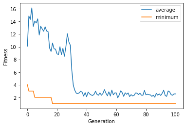

```python
import matplotlib.pyplot as plt
import numpy as np
%matplotlib inline
gen, avg, min_, max_ = log.select("gen", "avg", "min", "max")

plt.plot(gen, avg, label="average")
plt.plot(gen, min_, label="minimum")
plt.xlabel("Generation")
plt.ylabel("Fitness")
plt.legend(loc="upper right")
plt.show()
```

### 5 pts: Print out the best individual found and its fitness value. Show the best individual as chessboard

```python
best_ind = tools.selBest(pop, k=1)[0]

print('Best individual is:', best_ind)
print('With fitness: ', toolbox.evaluate(best_ind))
show_grid(best_ind)
```

```
Best individual is: [30, 2, 8, 19, 41, 55, 36, 61]
With fitness:  (1,)
-|-|X|-|-|-|-|-|

X|-|-|-|-|-|-|-|

-|-|-|X|-|-|-|-|

-|-|-|-|-|-|X|-|

-|-|-|-|X|-|-|-|

-|X|-|-|-|-|-|-|

-|-|-|-|-|-|-|X|

-|-|-|-|-|X|-|-|
```

## Part II: Row-index-based board representation

```python
import random
import numpy as np
from deap import algorithms, base, creator, tools

creator.create("FitnessMin", base.Fitness, weights=(-1.0,))
creator.create("Individual", list, fitness=creator.FitnessMin)
```

Each row of the chess row is indexed from 0->7 . we place different queens on different rows initially. The sequence [ a b c d .... ] means that in $0^{th}$ row, $a^{th}$ column, the queen is present and so on

```python
toolbox = base.Toolbox()

toolbox.register("attr_int", random.randint, 0, num_queens - 1)
toolbox.register("individual", tools.initRepeat, creator.Individual,
                 toolbox.attr_int, n=num_queens)
```

```python
toolbox.individual()
```

```
[7, 6, 7, 2, 0, 6, 4, 6]
```

```python
def show_grid(board):

    n = [0]*num_board

    for i in range(len(board)):
        n[board[i] + i*num_queens] = 1


    for i in range(num_queens):
        for j in range(num_board):
            if j // num_queens == i:
                if n[j] == 1:
                    print('X',end="|")
                else:
                    print('-',end="|")
        print()
        #print("----------------")
        print("")
```

```python
toolbox.register("population", tools.initRepeat, list, toolbox.individual)
```

```python
pop = toolbox.population(n=5)

print(pop[0])
```

```
[0, 2, 2, 6, 1, 3, 6, 1]
```

```python
show_grid(pop[0])
```

```
X|-|-|-|-|-|-|-|

-|-|X|-|-|-|-|-|

-|-|X|-|-|-|-|-|

-|-|-|-|-|-|X|-|

-|X|-|-|-|-|-|-|

-|-|-|X|-|-|-|-|

-|-|-|-|-|-|X|-|

-|X|-|-|-|-|-|-|
```

### 10 pts: Write your code in the cell below to define the "evaFitness" function, which return the fitness of any given board

- evaFitness() returns the total number of distinct pairs of queens that attack each other.
- The following are some test cases you may use to verify the correctness of the evaFitness() function:
  - evaFitness([0, 2, 6, 7, 7, 4, 1, 6]) should return (4,)
  - evaFitness([7, 5, 2, 4, 3, 1, 3, 5]) should return (6,)
  - evaFitness([3, 1, 6, 0, 5, 7, 2, 1]) should return (5,)
  - evaFitness([7, 3, 1, 4, 5, 1, 3, 5]) should return (6,)

```python
#fitness function
def evaFitness(individual):
    table=[0 for i in range(num_queens)]
    conflict = 0

    #column conflict
    for i in range (0,len(individual)):

        if(table[individual[i]] != 0):
            conflict +=table[individual[i]]
            table[individual[i]] += 1
        else:
            table[individual[i]] += 1

    #diagonal collision
    for i in range (0,len(individual) - 1):
        k = 1
        for j in range (i + 1, len(individual)):
            if(individual[i] == individual[j] + k):
                conflict += 1
            elif(individual[i] == individual[j] - k):
                conflict += 1
            k += 1

    return (conflict,)
```

```python
print(evaFitness([0, 2, 6, 7, 7, 4, 1, 6]))
print(evaFitness([7, 5, 2, 4, 3, 1, 3, 5]))
print(evaFitness([3, 1, 6, 0, 5, 7, 2, 1]))
print(evaFitness([7, 3, 1, 4, 5, 1, 3, 5]))
```

```
(4,)
(6,)
(5,)
(6,)
```

### 5 pts: Writer your code in the cell below to register "evaluate" function to toolbox

```python
toolbox.register("evaluate", evaFitness)
```

```python
toolbox.register("mate", tools.cxTwoPoint)

toolbox.register("mutate", tools.mutUniformInt, low = 0, up = num_queens - 1, indpb=0.1)

toolbox.register("select", tools.selTournament, tournsize=3)
```

```python
stats = tools.Statistics(key=lambda ind: ind.fitness.values)


stats.register("avg", np.mean)
stats.register("min", np.min)
```

### 10 pts: Writer your code in the cell below to create the first generation, the hall of fame, and launch the genetic algorithm: eaSimple(). Run the algorithm for 100 generations.

```python
pop = toolbox.population(n=1000)

hof = tools.HallOfFame(maxsize=1)

pop, log = algorithms.eaSimple(pop, toolbox, cxpb=0.5, mutpb=0.5, ngen=100,
                                   stats=stats, halloffame=hof, verbose=True)
```

```
gen	nevals	avg 	min
0  	1000  	7.88	2
1  	735   	6.609	2
2  	770   	5.844	1
3  	742   	5.458	1
4  	740   	5.095	1
5  	747   	4.814	1
6  	747   	4.65 	1
7  	760   	4.466	1
8  	776   	4.317	1
9  	750   	4.108	1
10 	735   	3.982	1
11 	714   	3.902	1
12 	722   	3.67 	1
13 	746   	3.643	0
```

[output cut: 87 more lines]

### 5 pts: Plot the "avg" and "min" for each generation

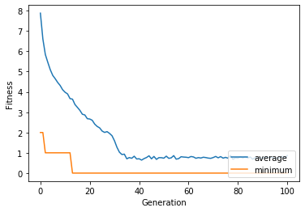

```python
# Plot the "avg" and "min" for each generation
import matplotlib.pyplot as plt
import numpy as np
%matplotlib inline
import matplotlib.pyplot as plt
import numpy as np
%matplotlib inline
gen, avg, min_, max_ = log.select("gen", "avg", "min", "max")

plt.plot(gen, avg, label="average")
plt.plot(gen, min_, label="minimum")
plt.xlabel("Generation")
plt.ylabel("Fitness")
plt.legend(loc="lower right")
plt.show()
```

### 5 pts: Print out the best individual found and its fitness value. Show the best individual as chessboard

```python
best_ind = tools.selBest(pop, k=1)[0]

print('Best individual is:', best_ind)
print('With fitness: ', toolbox.evaluate(best_ind))
show_grid(best_ind)
```

```
Best individual is: [3, 5, 7, 1, 6, 0, 2, 4]
With fitness:  (0,)
-|-|-|X|-|-|-|-|

-|-|-|-|-|X|-|-|

-|-|-|-|-|-|-|X|

-|X|-|-|-|-|-|-|

-|-|-|-|-|-|X|-|

X|-|-|-|-|-|-|-|

-|-|X|-|-|-|-|-|

-|-|-|-|X|-|-|-|
```

### Reflection: Which board representaion is better? Try different parameter values for mutation and crossover or vary the number of generations you want to go through, and write your findings in the report.

The row-index-based board representation provided better results usually resulting in an optimal fitness value of 0, while the position-index-based board representation usually achieved a minimum fitness value of 1